# Score-worms

2024-09-05

Functions have been added to fitzRoy to plot and analyse AFL score worms

- `plot_score_worm` - Plots the score difference between two teams throughout a given match.
- `plot_score_worm_totals` - Plots the total scores of both teams throughout a given match.
- `fetch_score_worm_data` - Returns score data used to plot score worms for a given match

# Working with score worms

The `plot_score_worm`, `plot_score_worm`, and `plot_score_worm` functions accepts the argument`match_id` to fetch the plot/data for a given match.

- `match_id` - the Champion Data match_id of the form CD_MSSSS014RRMM where SSSS is the Season, RR is the Round and MM is the Match. e.g. ‘CD_M20240142004’

## Examples

The following are some examples of ways to plot and scrape the score worm data.

Fist we can plot the score worm for the 2024 round 20 game between Fremantle and West Coast.

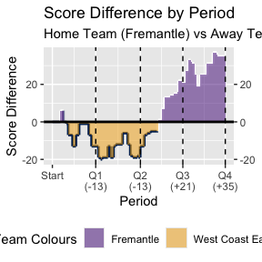

```r
plot_score_worm('CD_M20240142004')
```

We can also plot the total scores of each team throughout the game.

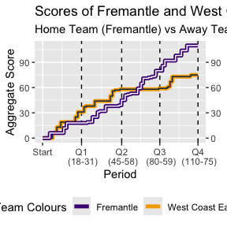

```r
plot_score_worm_totals('CD_M20240142004')
```

We can also just return the data for the fixture that can be used to construct these plots or for other score analysis.

```r
fetch_score_worm_data('CD_M20240142004')
```

```
#>    periodNumber TotalPeriodSeconds teamAbbr          teamName teamNickname
#> 1             1               1999     <NA>              <NA>         <NA>
#> 2             1               1999      FRE         Fremantle         Freo
#> 3             1               1999      WCE West Coast Eagles       Eagles
#> 4             1               1999      WCE West Coast Eagles       Eagles
#> 5             1               1999      WCE West Coast Eagles       Eagles
#> 6             1               1999      WCE West Coast Eagles       Eagles
#> 7             1               1999      FRE         Fremantle         Freo
#> 8             1               1999      FRE         Fremantle         Freo
#> 9             1               1999      WCE West Coast Eagles       Eagles
#> 10            1               1999      WCE West Coast Eagles       Eagles
#> 11            2               2061      WCE West Coast Eagles       Eagles
#> 12            2               2061      WCE West Coast Eagles       Eagles
#> 13            2               2061      FRE         Fremantle         Freo
#> 14            2               2061      FRE         Fremantle         Freo
```

[output cut: 321 more lines]

We can return multiple games worth of data by passing in a vector of match_ids.

```r
fetch_score_worm_data(c('CD_M20240142101','CD_M20240142102','CD_M20240142103'))
```

[output not shown]